# **Gerdau Challenge - Team Grace Hopper**

# Teste Análise de Dados

**Instruções:**

- Descreva a abordagem utilizada na resolução.
- Trechos de códigos deverão ter comentários essenciais.
- Haverá sessão de dúvidas, direcionando o entendimento dos problemas. **Não haverá comentário de solução**

## 1) Estudo do desempenho da siderurgia brasileira

A indústria do aço possui grande importância na indústria de transformação brasileira, na participação do PIB e na geração de empregos. Segundo o IABr (Instituto Aço Brasil) a produção de aço bruto brasileiro atingiu 32,6 milhões de toneladas em 2019, colocando o Brasil como o 9º maior produtor de aço no mundo. Foram 112 mil colaboradores, entre próprios e terceiros, que tornaram esse resultado possível.

https://acobrasil.org.br/

O desempenho da indústria siderúrgica depende do desempenho econômico do país. E vemos isso refletido no consumo de aço interno. Uma forma de avaliar o consumo de aço interno é através do consumo de aço aparente que é dado por:

**Consumo Aparente = Produção de Aço + Importação de Aço - Exportação de Aço**

Utilizando os dados históricos disponíveis no arquivo de excel "Performance_Mensal.xls" responda as seguintes pergutas e descreva o raciocínio utilizado.

#### **Importação e formatação dos dados**

```python
pip install --upgrade xlrd
```

```python
#imports
import pandas as pd
import seaborn as sns
import matplotlib.pyplot as plt
import requests
import os
```

```python
#função para baixar arquivo de site
def baixar_arquivo(url, endereco = 'Performance_Mensal.xls'):
    if endereco is None:
        endereco = os.path.basename(url.split("?")[0])
    resposta = requests.get(url, stream=True)
    if resposta.status_code == requests.codes.OK:
        with open(endereco, 'wb') as novo_arquivo:
            for parte in resposta.iter_content(chunk_size=256):
                novo_arquivo.write(parte)
        print("Download finalizado. Arquivo salvo em: {}".format(endereco))
    else:
        resposta.raise_for_status()
```

```python
#baixando o arquivo mais atualizado do site original
baixar_arquivo("https://acobrasil.org.br/site/wp-content/uploads/2022/04/Performance-Mensal_2022.03.xls")
```

```
Download finalizado. Arquivo salvo em: Performance_Mensal.xls
```

```python
#read data
#fonte: https://acobrasil.org.br/site/estatistica-mensal/
dados = pd.read_excel("Performance_Mensal.xls")
```

```python
#format data

def format_data(dados):
  ano = dados.iloc[2]
  mes = dados.iloc[3]
  prod_aco_bruto = dados.iloc[6]
  prod_laminados = dados.iloc[7]
  prod_laminados_planos = dados.iloc[8]
  prod_laminados_longos = dados.iloc[9]

  semiacabados_para_venda =dados.iloc[10]
  semiacabados_placas = dados.iloc[11]
  semiacabados_blocos_tarugos = dados.iloc[12]
  ferro_gusa = dados.iloc[13]

  vendas_internas = dados.iloc[14]
  vendas_internas_laminados = dados.iloc[15]
  vendas_internas_laminados_planos = dados.iloc[16]
  vendas_internas_laminados_longos = dados.iloc[17]

  vendas_internas_semiabacados_para_venda = dados.iloc[18]
  vendas_internas_semiabacabados_placas = dados.iloc[19]
  vendas_internas_semiabacabados_blocos = dados.iloc[20]

  vendas_externas = dados.iloc[21]
  vendas_externas_laminados = dados.iloc[22]
  vendas_externas_laminados_planos = dados.iloc[23]
  vendas_externas_laminados_longos = dados.iloc[24]

  vendas_externas_semiabacados_para_vendas = dados.iloc[25]
  vendas_externas_semiacabados_placas = dados.iloc[26]
  vendas_externas_blocos_tarugos = dados.iloc[27]


  exportacoes_laminados = dados.iloc[30]
  exportacoes_laminados_planos = dados.iloc[31]
  exportacoes_laminados_longos = dados.iloc[32]
  exportacoes_semiacabados_para_venda = dados.iloc[33]
  exportacoes_semiacabados_placas = dados.iloc[34]
  exportacoes_semiacabados_blocos_tarugos = dados.iloc[35]
  exportacoes_total_mil = dados.iloc[36]
  exportacoes_total_milhoes = dados.iloc[37]

  importacoes_laminados = dados.iloc[39]
  importacoes_laminados_planos = dados.iloc[40]
  importacoes_laminados_longos = dados.iloc[41]
  importacoes_semiacabados_para_vendas = dados.iloc[42]
  importacoes_total_mil = dados.iloc[43]
  importacoes_total_milhoes = dados.iloc[44]
  consumo_aparente = dados.iloc[45]
  consumo_aparente_planos = dados.iloc[46]
  consumo_aparente_longos = dados.iloc[47]

  for i in range(len(mes)):
    if(mes[i] == 'Jan\nJan'):
        mes[i] = 'Janeiro'
    elif(mes[i] == 'Fev\nFeb'):
        mes[i] = 'Fevereiro'
    elif(mes[i] == 'Mar\nMar'):
        mes[i] = 'Março'
    elif(mes[i] == 'Abr\nApr'):
        mes[i] = 'Abril'
    elif(mes[i] == 'Mai\nMay'):
        mes[i] = 'Maio'
    elif(mes[i] == 'Jun\nJun'):
        mes[i] = 'Junho'
    elif(mes[i] == 'Jul\nJul'):
        mes[i] = 'Julho'
    elif(mes[i] == 'Ago\nAug'):
        mes[i] = 'Agosto'
    elif(mes[i] == 'Set\nSep'):
        mes[i] = 'Setembro'
    elif(mes[i] == 'Out\nOct'):
        mes[i] = 'Outubro'
    elif(mes[i] == 'Nov\nNov'):
        mes[i] = 'Novembro'
    elif(mes[i] == 'Dez\nDez' or mes[i] == 'Dez\nDec'):
        mes[i] = 'Dezembro'

  trimestre = []

  for i in range(0, len(mes)):
      if(mes[i] == 'Janeiro' or mes[i] == 'Fevereiro' or mes[i] == 'Março'):
          trimestre.append(1)
      elif(mes[i] == 'Abril' or mes[i] == 'Maio' or mes[i] == 'Junho'):
          trimestre.append(2)
      elif(mes[i] == 'Julho' or mes[i] == 'Agosto' or mes[i] == 'Setembro'):
          trimestre.append(3)
      elif(mes[i] == 'Outubro' or mes[i] == 'Novembro' or mes[i] == 'Dezembro'):
          trimestre.append(4)
      else:
          trimestre.append('Nan')

  qtd_linhas = len(ano)
  qtd_ano = int(len(ano)/12)
  qtd_ano_incompleto = len(ano)%12

  linhas = 1
  ano_atual = int(ano[linhas])

  while(qtd_ano > 0):
      for i in range(0,12):
          ano[linhas] = ano_atual
          linhas += 1
      qtd_ano -= 1
      ano_atual += 1


  for i in range(0,qtd_ano_incompleto-1):
      ano[linhas] = ano_atual
      linhas += 1

  dict = {'Ano':ano,
        'Mes':mes,
        'Trimestre':trimestre,
        'Prod Aco Bruto':prod_aco_bruto,
        'Prod Laminados':prod_laminados,
        'Prod Laminados Planos':prod_laminados_planos,
        'Prod Laminados Longos':prod_laminados_longos,
        'Semiacabados P/ Venda':semiacabados_para_venda,
        'Semiacabados Placas':semiacabados_placas,
        'Semiacabados Blocos e Tarugos':semiacabados_blocos_tarugos,
        'Ferro Gusa':ferro_gusa,
        'Vendas Internas':vendas_internas,
        'Vendas Internas Laminados':vendas_internas_laminados,
        'Vendas Internas Laminados Planos':vendas_internas_laminados_planos,
        'Vendas Internas Laminados Longos':vendas_internas_laminados_longos,
        'Vendas Externas':vendas_externas,
        'Vendas Externas Laminados':vendas_externas_laminados,
        'Vendas Externas Laminados Planos':vendas_externas_laminados_planos,
        'Vendas Externas Laminados Longos':vendas_externas_laminados_longos,
        'Vendas Exeternas Semiacabados P/ Venda':vendas_externas_semiabacados_para_vendas,
        'Venadas Externas Semiacabados Placas':vendas_externas_semiacabados_placas,
        'Venas Externas Semiacabados Blocos e Tarugos':vendas_externas_blocos_tarugos,
        'Exportações Laminados':exportacoes_laminados,
        'Exportações Laminados Planos':exportacoes_laminados_planos,
        'Exportações Laminados Longos':exportacoes_laminados_longos,
        'Exportações Semiacabados P/ Venda':exportacoes_semiacabados_para_venda,
        'Exportações Semiacabados Placas':exportacoes_semiacabados_placas,
        'Exportações Semiacabados Blocos e Tarugos':exportacoes_semiacabados_blocos_tarugos,
        'Exportações Total Mil t':exportacoes_total_mil,
        'Exportações Total US$ Milhões':exportacoes_total_milhoes,
        'Importações Laminados':importacoes_laminados,
        'Importações Laminados Planos':importacoes_laminados_planos,
        'Importações Laminados Longos':importacoes_laminados_longos,
        'Importações Semiacabados P/ Venda':importacoes_semiacabados_para_vendas,
        'Importações Total Mil t':importacoes_total_mil,
        'Importações Total US$ Milhões':importacoes_total_milhoes,
        'Consumo Aparente':consumo_aparente,
        'Consumo Aparente Planos':consumo_aparente_planos,
        'Consumo Aparente Longos':consumo_aparente_longos
       }

  data = pd.DataFrame(dict)
  data = data.drop(data.index[0])
  data_clear=data.reset_index(drop=True)

  return data_clear
```

```python
data_clear = format_data(dados)
data_clear
```

|  | Ano | Mes | Trimestre | Prod Aco Bruto | Prod Laminados | Prod Laminados Planos | Prod Laminados Longos | Semiacabados P/ Venda | Semiacabados Placas | Semiacabados Blocos e Tarugos | ... | Exportações Total US$ Milhões | Importações Laminados | Importações Laminados Planos | Importações Laminados Longos | Importações Semiacabados P/ Venda | Importações Total Mil t | Importações Total US$ Milhões | Consumo Aparente | Consumo Aparente Planos | Consumo Aparente Longos |
| --- | --- | --- | --- | --- | --- | --- | --- | --- | --- | --- | --- | --- | --- | --- | --- | --- | --- | --- | --- | --- | --- |
| 0 | 2013 | Janeiro | 1 | 2769.437 | 2051.441 | 1202.482 | 848.959 | 470.371 | 394.66 | 75.711 | ... | 573.5 | 277.653 | 140.752 | 136.901 | 1.196 | 278.849 | 369.978 | 2167.705 | 1261.809 | 905.896 |
| 1 | 2013 | Fevereiro | 1 | 2574.894 | 1942.836 | 1144.078 | 798.758 | 480.793 | 417.568 | 63.225 | ... | 509.969 | 294.211 | 155.913 | 138.298 | 0.16 | 294.371 | 311.089 | 2069.84 | 1195.402 | 874.438 |
| 2 | 2013 | Março | 1 | 2858.521 | 2194.384 | 1261.646 | 932.738 | 550.726 | 435.452 | 115.274 | ... | 474.159 | 271.067 | 140.296 | 130.771 | 0.288 | 271.355 | 322.156 | 2330.914 | 1311.942 | 1018.972 |
| 3 | 2013 | Abril | 2 | 2913.622 | 2211.587 | 1233.065 | 978.522 | 459.709 | 386.75 | 72.959 | ... | 539.518 | 329.344 | 188.103 | 141.241 | 0.523 | 329.867 | 373.559 | 2402.633 | 1367.514 | 1035.119 |
| 4 | 2013 | Maio | 2 | 2999.775 | 2354.716 | 1311.414 | 1043.302 | 442.191 | 346.131 | 96.06 | ... | 507.626 | 264.948 | 148.586 | 116.362 | 1.496 | 266.444 | 342.873 | 2456.82 | 1403.178 | 1053.642 |
| ... | ... | ... | ... | ... | ... | ... | ... | ... | ... | ... | ... | ... | ... | ... | ... | ... | ... | ... | ... | ... | ... |
| 107 | 2021 | Dezembro | 4 | 2656.907 | 1783.452 | 1188.671 | 594.781 | 867.706 | 764.693 | 103.013 | ... | 1177.935 | 308.195 | 196.884 | 111.311 | 0.39 | 308.585 | 398.614 | 1729.475 | 1003.506 | 725.969 |
| 108 | 2022 | Janeiro | 1 | 2882.699 | 1980.484 | 1188.755 | 791.729 | 795.657 | 738.42 | 57.237 | ... | 1041.548 | 294.802 | 206.074 | 88.728 | 0.818 | 295.62 | 407.307 | 1702.632 | 1010.548 | 692.084 |
| 109 | 2022 | Fevereiro | 1 | 2674.622 | 1844.731 | 1047.107 | 797.624 | 610.897 | 539.513 | 71.384 | ... | 767.865 | 281.64 | 179.744 | 101.896 | 15.731 | 297.371 | 388.802 | 1812.211 | 1054.89 | 757.321 |
| 110 | 2022 | Março | 1 | 2945.523 | 2122.239 | 1202.242 | 919.997 | 683.356 | 573.104 | 110.252 | ... | 992.821 | 237.232 | 158.946 | 78.286 | 6.54 | 243.772 | 374.818 | 2079.107 | 1187.851 | 891.256 |
| 111 | 2022 | NaN | Nan | 10.128571 | 15.043277 | 14.815582 | 15.342191 | 11.861083 | 6.226171 | 54.449176 | ... | 29.296296 | -15.767647 | -11.570901 | -23.170684 | -58.426038 | -18.024286 | -3.596689 | 14.727645 | 12.604253 | 17.685367 |

112 rows × 39 columns

### **a.** As exportações de aço brasileiras são representativas no mercado internacional, o Brasil foi o 12º maior exportador de produtos siderúrgicos em 2019. Qual foi o trimestre em que houve a maior exportação de aço? Qual foi o preço aproximado? É possivel identificar alguma relação entre preço e quantidade exportada?

#### **Funções**

```python
# função para soma anual do total de exportação
def soma_anual(dados,coluna):
    soma = dados.groupby('Ano').agg({coluna: 'sum'}).reset_index()
    return soma
```

```python
# função para gerar gráfico da comparação entre duas variáveis
def grafico_comparacao(figura,identificador,dados,eixo_x, eixo_y1, eixo_y2):
    figura.add_subplot(identificador)
    plt.plot(dados[eixo_x], dados[eixo_y1], linestyle='--', marker='o', color = 'blue', markersize = 4)
    plt.plot(dados[eixo_x], dados[eixo_y2], linestyle='--', marker='o', color = 'red', markersize = 4)
    plt.xlabel(eixo_x, fontsize=12)
    plt.legend([eixo_y1,eixo_y2], fontsize=11)
```

```python
# maiores valores anual do preço e quantidade exportada de aço
def maior_valor_anual(dados,coluna):
    valor_maior_todos_anos = dados.agg({coluna: 'max'}).reset_index()
    maior_ano = dados[dados[coluna] == valor_maior_todos_anos[0][0]]['Ano'].reset_index()
    return maior_ano.iloc[0,1],valor_maior_todos_anos[0][0]
```

```python
# valor exportado de aço de um único ano
def valor_ano(dados,coluna,ano):
    valor = dados[dados.Ano == ano][coluna].reset_index()
    return valor.iloc[0,1].round(2)
```

```python
# soma em trimestre de uma variável
def soma_trimestral(dados,coluna):
    soma_todos_trimestres = pd.DataFrame()
    soma_trimestre = dados.groupby('Ano').agg({coluna: 'sum'}).reset_index()
    soma_todos_trimestres['Ano']=soma_trimestre['Ano']
    for i in range(1, 5):
        soma_trimestre = dados[dados.Trimestre == i].groupby(
                        'Ano').agg({coluna: 'sum'}).reset_index()
        soma_trimestre = soma_trimestre.rename(
                    {coluna: '{} T{}'.format(coluna,i)}, axis=1)
        soma_todos_trimestres['{} T{}'.format(coluna,i)]=soma_trimestre['{} T{}'.format(coluna,i)]
    return soma_todos_trimestres
```

```python
# função para criar um gráfico de algum valor da base em trimestre
def grafico_trimestral(soma_todos_trimestres,coluna):
    plt.figure(figsize=(10, 5))
    plt.plot(soma_todos_trimestres['Ano'], soma_todos_trimestres[soma_todos_trimestres.columns[1]], linestyle='--', marker='o', color = 'orange', markersize = 4)
    plt.plot(soma_todos_trimestres['Ano'], soma_todos_trimestres[soma_todos_trimestres.columns[2]], linestyle='--', marker='o', color = 'red', markersize = 4)
    plt.plot(soma_todos_trimestres['Ano'], soma_todos_trimestres[soma_todos_trimestres.columns[3]], linestyle='--', marker='o', color = 'green', markersize = 4)
    plt.plot(soma_todos_trimestres['Ano'], soma_todos_trimestres[soma_todos_trimestres.columns[4]], linestyle='--', marker='o', color = 'blue', markersize = 4)
    plt.xlabel('Anos', fontsize=15)
    plt.ylabel(coluna, fontsize=15)
    plt.legend(['1º Trimestre','2º Trimestre','3º Trimestre','4º Trimestre'], fontsize=14)
    axes = plt.gca()
    axes.yaxis.grid(b=True, color='black', alpha=0.3, linestyle='-.', linewidth=1)
    plt.show()
```

```python
# maior valor entre os trimestres do ano
def maior_trimestre_de_cada_ano(soma_todos_trimestres):
    soma_todos_trimestres['Maior Trimestre'] = soma_todos_trimestres.iloc[:,1:].fillna(0).max(axis=1)
    return soma_todos_trimestres
```

```python
# função para localizar trimestre de maior valor de todos os anos registrados, retornando o trimestre, ano e valor
def maior_trimestre_dos_anos(dados,coluna):
    localizacao_maior_valor = pd.DataFrame()
    index_todos_anos = 0
    maior_valor = dados.agg({'Maior Trimestre': 'max'}).reset_index()

    while (localizacao_maior_valor.size == 0):
        index_todos_anos = index_todos_anos + 1
        localizacao_maior_valor = dados[dados['{} T{}'.format(coluna,index_todos_anos)] == maior_valor[0][0]]

    return index_todos_anos,localizacao_maior_valor.iloc[0,0],maior_valor[0][0].round(2)
```

```python
# função para localizar o maior valor trimestral de aço de um único ano
def maior_trimestre_do_ano(dados,coluna,ano):
    localizacao_maior_valor = pd.DataFrame()
    index = 0
    maior_trimestre = dados[dados.Ano == ano].iloc[:,1:].fillna(0).max(axis=1).reset_index()
    while (localizacao_maior_valor.size == 0):
        index = index + 1
        localizacao_maior_valor = dados[dados['{} T{}'.format(coluna,index)] == maior_trimestre[0][0]]

    return index,maior_trimestre[0][0]
```

#### **Ano que houve a maior valor em exportação de aço**:

```python
# soma anual do total de exportação em toneladas
toneladas = soma_anual(data_clear,'Exportações Total Mil t')
# soma anual do total do preço da exportação em dolar
dolar = soma_anual(data_clear,'Exportações Total US$ Milhões')
```

```python
# união dos totais de toneladas e preço em dolar
toneladas_dolar = toneladas.merge(dolar, on='Ano', how='outer')
toneladas_dolar
```

|  | Ano | Exportações Total Mil t | Exportações Total US$ Milhões |
| --- | --- | --- | --- |
| 0 | 2013 | 8090.640000 | 5567.386000 |
| 1 | 2014 | 9780.952000 | 6808.335000 |
| 2 | 2015 | 13726.000000 | 6585.000000 |
| 3 | 2016 | 13432.000000 | 5594.000000 |
| 4 | 2017 | 15351.000000 | 8046.000000 |
| 5 | 2018 | 13945.000000 | 8874.000000 |
| 6 | 2019 | 12804.816000 | 7307.965000 |
| 7 | 2020 | 10537.925000 | 5270.964000 |
| 8 | 2021 | 10974.559000 | 9345.149000 |
| 9 | 2022 | 3472.677213 | 2831.530296 |

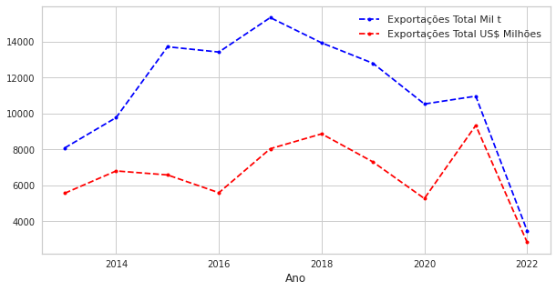

```python
# gráfico de comparação entre a quantidade e preço total exportado
fig=plt.figure(figsize=(10, 5))
grafico_comparacao(fig,111,toneladas_dolar,toneladas_dolar.columns[0], toneladas_dolar.columns[1],toneladas_dolar.columns[2])
```

```python
# ano que teve a maior quantidade de exportação em toneladas
ano_toneladas, maior_valor_anual_toneladas = maior_valor_anual(toneladas_dolar,toneladas_dolar.columns[1])
print("O ano que mais exportou em quantidade de aço foi {}, totalizando {} mil toneladas.".format(ano_toneladas, maior_valor_anual_toneladas))
# ano que teve a maior quantidade de exportação em dolar
ano_dolar, maior_valor_anual_dolar = (maior_valor_anual(toneladas_dolar,toneladas_dolar.columns[2]))
print("O ano que mais faturou em exportação de aço foi {}, totalizando US$ {} milhões.".format(ano_dolar, maior_valor_anual_dolar))
```

```
O ano que mais exportou em quantidade de aço foi 2017, totalizando 15351.0 mil toneladas.
O ano que mais faturou em exportação de aço foi 2021, totalizando US$ 9345.149 milhões.
```

```python
# quantidade e preço da exportação de aço em 2019 em toneladas
valor_toneladas_2019 = valor_ano(toneladas_dolar,toneladas_dolar.columns[1],2019)
valor_dolar_2019 = valor_ano(toneladas_dolar,toneladas_dolar.columns[2],2019)
print("Em 2019 foi exportado um total de {} mil toneladas de aço e rebeceu US$ {} milhões.".format(valor_toneladas_2019,valor_dolar_2019))
```

```
Em 2019 foi exportado um total de 12804.82 mil toneladas de aço e rebeceu US$ 7307.96 milhões.
```

#### **Qual foi o trimestre em que houve a maior exportação de aço?**

```python
# soma em trimestre da quantidade de aço exportado em toneladas
soma_todos_trimestres_toneladas = soma_trimestral(data_clear,'Exportações Total Mil t')
soma_todos_trimestres_toneladas
```

|  | Ano | Exportações Total Mil t T1 | Exportações Total Mil t T2 | Exportações Total Mil t T3 | Exportações Total Mil t T4 |
| --- | --- | --- | --- | --- | --- |
| 0 | 2013 | 2466.755 | 1967.943 | 1683.369 | 1972.573 |
| 1 | 2014 | 1995.544 | 1928.358 | 2832.753 | 3024.297 |
| 2 | 2015 | 2782.000 | 2949.000 | 4312.000 | 3683.000 |
| 3 | 2016 | 3257.000 | 3428.000 | 3382.000 | 3365.000 |
| 4 | 2017 | 3822.000 | 3478.000 | 3703.000 | 4348.000 |
| 5 | 2018 | 3578.000 | 3302.000 | 2641.000 | 4424.000 |
| 6 | 2019 | 3291.510 | 3398.041 | 2872.202 | 3243.063 |
| 7 | 2020 | 3212.155 | 2796.319 | 2465.028 | 2064.423 |
| 8 | 2021 | 2684.370 | 2525.153 | 1689.585 | 3131.002 |
| 9 | 2022 | 3442.877 | NaN | NaN | NaN |

```python
# soma em trimestre do preço de aço exportado em dolar
soma_todos_trimestres_dolar = soma_trimestral(data_clear,'Exportações Total US$ Milhões')
soma_todos_trimestres_dolar
```

|  | Ano | Exportações Total US$ Milhões T1 | Exportações Total US$ Milhões T2 | Exportações Total US$ Milhões T3 | Exportações Total US$ Milhões T4 |
| --- | --- | --- | --- | --- | --- |
| 0 | 2013 | 1557.628 | 1433.323 | 1202.835 | 1373.600 |
| 1 | 2014 | 1451.295 | 1461.014 | 1954.826 | 1941.200 |
| 2 | 2015 | 1765.000 | 1518.000 | 1880.000 | 1422.000 |
| 3 | 2016 | 1189.000 | 1360.000 | 1579.000 | 1466.000 |
| 4 | 2017 | 1850.000 | 1849.000 | 1911.000 | 2436.000 |
| 5 | 2018 | 2153.000 | 2139.000 | 1819.000 | 2763.000 |
| 6 | 2019 | 1954.465 | 2061.589 | 1642.520 | 1649.391 |
| 7 | 2020 | 1622.371 | 1374.201 | 1148.686 | 1125.706 |
| 8 | 2021 | 1743.029 | 2124.708 | 1659.983 | 2880.152 |
| 9 | 2022 | 2802.234 | NaN | NaN | NaN |

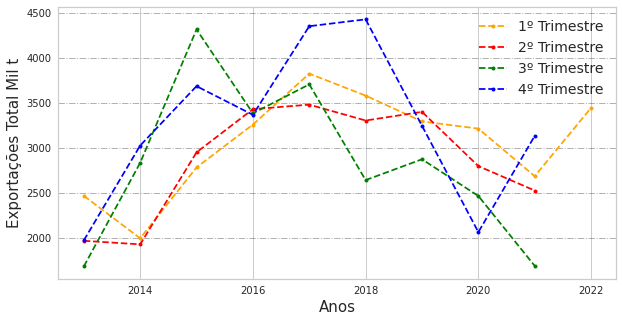

```python
# gráfico da quantidade em toneladas de aço exportado divido em trimestre
grafico_trimestral(soma_todos_trimestres_toneladas,toneladas_dolar.columns[1])
```

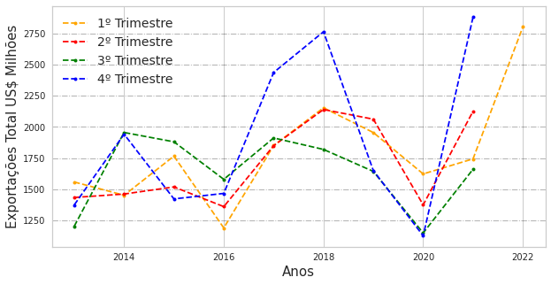

```python
# gráfico do preço em dolar do aço exportado divido em trimestre
grafico_trimestral(soma_todos_trimestres_dolar,toneladas_dolar.columns[2])
```

```python
# maior valor de quantidade de toneladas de aço exportado entre trimestres de cada ano
soma_todos_trimestres_toneladas = maior_trimestre_de_cada_ano(soma_todos_trimestres_toneladas)
soma_todos_trimestres_toneladas
```

|  | Ano | Exportações Total Mil t T1 | Exportações Total Mil t T2 | Exportações Total Mil t T3 | Exportações Total Mil t T4 | Maior Trimestre |
| --- | --- | --- | --- | --- | --- | --- |
| 0 | 2013 | 2466.755 | 1967.943 | 1683.369 | 1972.573 | 2466.755 |
| 1 | 2014 | 1995.544 | 1928.358 | 2832.753 | 3024.297 | 3024.297 |
| 2 | 2015 | 2782.000 | 2949.000 | 4312.000 | 3683.000 | 4312.000 |
| 3 | 2016 | 3257.000 | 3428.000 | 3382.000 | 3365.000 | 3428.000 |
| 4 | 2017 | 3822.000 | 3478.000 | 3703.000 | 4348.000 | 4348.000 |
| 5 | 2018 | 3578.000 | 3302.000 | 2641.000 | 4424.000 | 4424.000 |
| 6 | 2019 | 3291.510 | 3398.041 | 2872.202 | 3243.063 | 3398.041 |
| 7 | 2020 | 3212.155 | 2796.319 | 2465.028 | 2064.423 | 3212.155 |
| 8 | 2021 | 2684.370 | 2525.153 | 1689.585 | 3131.002 | 3131.002 |
| 9 | 2022 | 3442.877 | NaN | NaN | NaN | 3442.877 |

```python
# maior valor do preço em dolar do aço exportado entre trimestres de cada ano
soma_todos_trimestres_dolar = maior_trimestre_de_cada_ano(soma_todos_trimestres_dolar)
soma_todos_trimestres_dolar
```

|  | Ano | Exportações Total US$ Milhões T1 | Exportações Total US$ Milhões T2 | Exportações Total US$ Milhões T3 | Exportações Total US$ Milhões T4 | Maior Trimestre |
| --- | --- | --- | --- | --- | --- | --- |
| 0 | 2013 | 1557.628 | 1433.323 | 1202.835 | 1373.600 | 1557.628 |
| 1 | 2014 | 1451.295 | 1461.014 | 1954.826 | 1941.200 | 1954.826 |
| 2 | 2015 | 1765.000 | 1518.000 | 1880.000 | 1422.000 | 1880.000 |
| 3 | 2016 | 1189.000 | 1360.000 | 1579.000 | 1466.000 | 1579.000 |
| 4 | 2017 | 1850.000 | 1849.000 | 1911.000 | 2436.000 | 2436.000 |
| 5 | 2018 | 2153.000 | 2139.000 | 1819.000 | 2763.000 | 2763.000 |
| 6 | 2019 | 1954.465 | 2061.589 | 1642.520 | 1649.391 | 2061.589 |
| 7 | 2020 | 1622.371 | 1374.201 | 1148.686 | 1125.706 | 1622.371 |
| 8 | 2021 | 1743.029 | 2124.708 | 1659.983 | 2880.152 | 2880.152 |
| 9 | 2022 | 2802.234 | NaN | NaN | NaN | 2802.234 |

```python
# retorno do trimestre que teve o maior valor exportado em toneladas
maior_trimestre_toneladas,ano_do_maior_trimestre,maior_valor_toneladas = maior_trimestre_dos_anos(soma_todos_trimestres_toneladas,'Exportações Total Mil t')
print('O trimestre que teve maior quantidade de aço exportado foi o {}º de {}, com {} mil toneladas.'.format(maior_trimestre_toneladas,ano_do_maior_trimestre,maior_valor_toneladas))
# retorno do trimestre que teve o maior valor exportado em dolar
maior_trimestre_dolar,ano_do_maior_trimestre,maior_valor_dolar = maior_trimestre_dos_anos(soma_todos_trimestres_dolar,'Exportações Total US$ Milhões')
print('O trimestre que teve maior valor recebido de aço exportado foi o {}º de {}, com US$ {} milhões.'.format(maior_trimestre_dolar,ano_do_maior_trimestre,maior_valor_dolar))
```

```
O trimestre que teve maior quantidade de aço exportado foi o 4º de 2018, com 4424.0 mil toneladas.
O trimestre que teve maior valor recebido de aço exportado foi o 4º de 2021, com US$ 2880.15 milhões.
```

```python
# retorno do trimestre que teve o maior valor exportado em toneladas do ano de 2019
maior_trimestre_toneladas_2021,maior_valor_toneladas_2021 = maior_trimestre_do_ano(soma_todos_trimestres_toneladas,'Exportações Total Mil t',2021)
# retorno do trimestre que teve o maior valor exportado em dolar do ano de 2019
maior_trimestre_dolar_2021,maior_valor_dolar_2021 = maior_trimestre_do_ano(soma_todos_trimestres_dolar,'Exportações Total US$ Milhões',2021)
print('Em 2021 o maior trimestre exportado de aço foi o {}º, com {} mil toneladas, com valor total recebido de US$ {} milhões.'.format(maior_trimestre_toneladas_2021,maior_valor_toneladas_2021.round(2),maior_valor_dolar_2021.round(2)))
```

```
Em 2021 o maior trimestre exportado de aço foi o 4º, com 3131.0 mil toneladas, com valor total recebido de US$ 2880.15 milhões.
```

```python
# retorno do trimestre que teve o maior valor exportado em toneladas do ano de 2019
maior_trimestre_toneladas_2019,maior_valor_toneladas_2019 = maior_trimestre_do_ano(soma_todos_trimestres_toneladas,'Exportações Total Mil t',2019)
# retorno do trimestre que teve o maior valor exportado em dolar do ano de 2019
maior_trimestre_dolar_2019, maior_valor_dolar_2019 = maior_trimestre_do_ano(soma_todos_trimestres_dolar,'Exportações Total US$ Milhões',2019)
print('Em 2019 o maior trimestre exportado de aço foi o {}º, com {} mil toneladas, com valor total recebido de US$ {} milhões.'.format(maior_trimestre_toneladas_2019,maior_valor_toneladas_2019,maior_valor_dolar_2019))
```

```
Em 2019 o maior trimestre exportado de aço foi o 2º, com 3398.041 mil toneladas, com valor total recebido de US$ 2061.589 milhões.
```

#### **Qual foi o preço aproximado?**

```python
# conclusão e média do preço
# média de 2021
media_preco_tonelada_2021 = ((maior_valor_dolar_2021*1000000)/(maior_valor_toneladas_2021*1000)).round(2)
# média de 2019
media_preco_tonelada_2019 = ((maior_valor_dolar_2019*1000000)/(maior_valor_toneladas_2019*1000)).round(2)

print("""De acordo com os dados apresentados, o ano que mais exportou foi {} com {} mil toneladas de aço, em contrapatida o ano que teve maior rendimento foi {}, com US$ {} milhões.
Em 2019 a quantidade exportada de aço foi {} mil toneladas, com o preço total de US$ {} milhões.

O {}º trimestre de {} teve o maior valor em dólar de exportação de aço entre todos os anos, foram {} mil toneladas, com um total de US$ {} milhões. O preço aproximado nesse período foi de US$ {} por tonelada.
Já no ano de 2019 os valores foram menores, seu maior trimestre foi o {}º, com {} mil toneladas de aço exportado, um rendimento de US$ {} milhóes, e média de US$ {} por tonelada.
""".format(ano_toneladas, maior_valor_anual_toneladas,ano_dolar, maior_valor_anual_dolar, valor_toneladas_2019,valor_dolar_2019,maior_trimestre_toneladas_2021,ano_do_maior_trimestre,maior_valor_toneladas_2021.round(2),maior_valor_dolar_2021.round(2),media_preco_tonelada_2021.round(2),maior_trimestre_toneladas_2019,maior_valor_toneladas_2019,maior_valor_dolar_2019,media_preco_tonelada_2019))
```

```
De acordo com os dados apresentados, o ano que mais exportou foi 2017 com 15351.0 mil toneladas de aço, em contrapatida o ano que teve maior rendimento foi 2021, com US$ 9345.149 milhões.
Em 2019 a quantidade exportada de aço foi 12804.82 mil toneladas, com o preço total de US$ 7307.96 milhões.

O 4º trimestre de 2021 teve o maior valor em dólar de exportação de aço entre todos os anos, foram 3131.0 mil toneladas, com um total de US$ 2880.15 milhões. O preço aproximado nesse período foi de US$ 919.88 por tonelada.
Já no ano de 2019 os valores foram menores, seu maior trimestre foi o 2º, com 3398.041 mil toneladas de aço exportado, um rendimento de US$ 2061.589 milhóes, e média de US$ 606.7 por tonelada.
```

#### **É possivel identificar alguma relação entre preço e quantidade exportada?**

```python
# seleção da coluna de preço e de quantidade
correlacao = data_clear[['Exportações Total Mil t','Exportações Total US$ Milhões']]
# informação das variáveis
correlacao.info()
```

```
<class 'pandas.core.frame.DataFrame'>
RangeIndex: 112 entries, 0 to 111
Data columns (total 2 columns):
 #   Column                         Non-Null Count  Dtype
---  ------                         --------------  -----
 0   Exportações Total Mil t        112 non-null    object
 1   Exportações Total US$ Milhões  112 non-null    object
dtypes: object(2)
memory usage: 1.9+ KB
```

```python
# para a correlação, neste caso, se faz necessário a transformação para tipo numérico
correlacao = correlacao.astype(float, errors = 'raise')
correlacao.info()
```

```
<class 'pandas.core.frame.DataFrame'>
RangeIndex: 112 entries, 0 to 111
Data columns (total 2 columns):
 #   Column                         Non-Null Count  Dtype
---  ------                         --------------  -----
 0   Exportações Total Mil t        112 non-null    float64
 1   Exportações Total US$ Milhões  112 non-null    float64
dtypes: float64(2)
memory usage: 1.9 KB
```

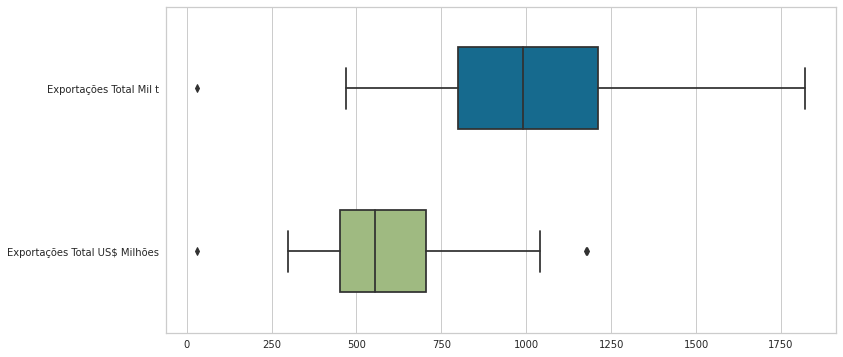

```python
# verificando se os dados possuem discrepância
ax = sns.boxplot(data=correlacao, orient='h', width=0.5)
ax.figure.set_size_inches(12, 6)
ax;
```

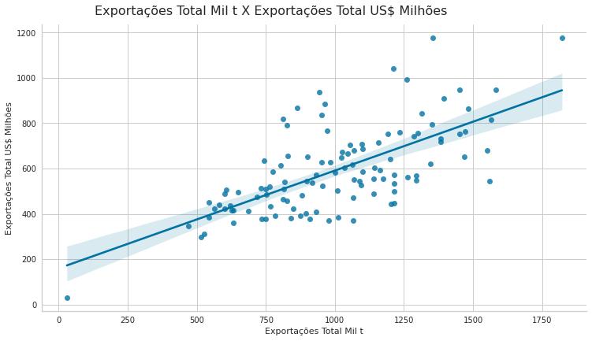

```python
# gráfico para visualizar se as colunas estão correlacionadas
ax = sns.lmplot(x = 'Exportações Total Mil t', y ='Exportações Total US$ Milhões', data=correlacao)
ax.fig.set_size_inches(12, 6)
ax.fig.suptitle('Exportações Total Mil t X Exportações Total US$ Milhões', fontsize=16, y=1.02)
ax;
```

```python
# matriz de correlação
matriz_corr = correlacao.corr().reset_index()
matriz_corr
```

|  | index | Exportações Total Mil t | Exportações Total US$ Milhões |
| --- | --- | --- | --- |
| 0 | Exportações Total Mil t | 1.000000 | 0.676153 |
| 1 | Exportações Total US$ Milhões | 0.676153 | 1.000000 |

```python
# conclusão
# fonte: https://psicometriaonline.com.br/o-que-e-correlacao-de-pearson/
print("""É possível medir a intensidade da relação linear, se ela é mais forte ou se ela é mais fraca, vendo numericamente. O coeficiente de correlação vai variar de -1 a 1, onde perto desses extremos, -1 e 1, indicam relações mais fortes entre as duas variáveis, relações lineares.

Cohen (1992) sugere os seguintes tamanhos de efeito:
* r = |0,10| -> correlação fraca.
* r = |0,30| -> correlação moderada.
* r = |0,50| -> correlação forte.

O artigo “How to Interpret a Correlation Coefficient r – dummies” (2019) sugere que:
* r = |0,30| -> correlação fraca
* r = |0,50| -> correlação moderada
* r = |0,70| -> correlação forte

Sendo assim, o preço e a quantidade de aço exportado estão correlacionados moderadamente positivo com {}.""".format(matriz_corr.iloc[0,2].round(4)))
```

```
É possível medir a intensidade da relação linear, se ela é mais forte ou se ela é mais fraca, vendo numericamente. O coeficiente de correlação vai variar de -1 a 1, onde perto desses extremos, -1 e 1, indicam relações mais fortes entre as duas variáveis, relações lineares.

Cohen (1992) sugere os seguintes tamanhos de efeito:
* r = |0,10| -> correlação fraca.
* r = |0,30| -> correlação moderada.
* r = |0,50| -> correlação forte.

O artigo “How to Interpret a Correlation Coefficient r – dummies” (2019) sugere que:
* r = |0,30| -> correlação fraca
* r = |0,50| -> correlação moderada
* r = |0,70| -> correlação forte

Sendo assim, o preço e a quantidade de aço exportado estão correlacionados moderadamente positivo com 0.6762.
```

### **b.** Dado que o desempenho da siderurgia está ligado ao desempenho econômico do país, utilize a série histórica do consumo aparente de aço brasileiro e faça uma análise exploratória, explicando as mudanças de tendência observadas.

#### **Funções**

```python
def grafico_comparacao_trimestral(figura,identificador,dados,eixo_x, eixo_y1, eixo_y2):
    figura.add_subplot(identificador)
    plt.plot(dados[eixo_x], dados[eixo_y1], linestyle='--', marker='o', color = 'blue', markersize = 4)
    plt.plot(dados[eixo_x], dados[eixo_y2], linestyle='--', marker='o', color = 'red', markersize = 4)
    plt.xlabel('Trimestres', fontsize=12)
    plt.xticks(rotation=90,fontsize=13)
    plt.legend([eixo_y1,eixo_y2], fontsize=11)
```

```python
# função para gerar gráfico de uma variável
def grafico_trimestral(figura,identificador,dados,eixo_x, eixo_y,cor):
    figura.add_subplot(identificador)
    plt.plot(dados[eixo_x], dados[eixo_y], linestyle='--', marker='o', color = cor, markersize = 4)
    plt.ylabel(eixo_y, fontsize=15)
    plt.xlabel('Trimestres', fontsize = 15)
    plt.xticks(rotation=90,fontsize=13)
    plt.title(eixo_y, fontsize=18)
```

```python
# separar o ano do mês
def separar_ano_mes(dados):
    dados[['Ano','Mes']]=dados['Data'].astype(str).str.split('.',expand=True)
    dados.drop(columns=['Data'], axis=1, inplace=True)
    return dados
```

```python
# adicionar uma coluna identificando trimestre que aquele mês pertence
def adicionar_trimestre(dados):
    dados['Trimestre']=''
    # dados['Mes'] = dados['Mes'].astype(int)
    for i in range(0, len(dados)):
        if(dados['Mes'][i] == '01' or dados['Mes'][i] == '02' or dados['Mes'][i] == '03'):
            dados['Trimestre'][i] = '1'
        elif(dados['Mes'][i] == '04' or dados['Mes'][i] == '05' or dados['Mes'][i] == '06'):
            dados['Trimestre'][i] = '2'
        elif(dados['Mes'][i] == '07' or dados['Mes'][i] == '08' or dados['Mes'][i] == '09'):
            dados['Trimestre'][i] = '3'
        elif(dados['Mes'][i] == '10' or dados['Mes'][i] == '11' or dados['Mes'][i] == '12'):
            dados['Trimestre'][i] = '4'
    dados = dados.drop(columns=['Mes'])
    return dados
```

```python
# separar o ano do trimestre
def separar_ano_trimestre(dados):
    dados[['Ano','Trimestre']]=dados['Data'].astype(str).str.split(' T',expand=True)
    dados.drop(columns=['Data'], axis=1, inplace=True)
    return dados
```

```python
! pip install BeautifulSoup4
! pip install lxml
```

```python
import urllib.request
from bs4 import BeautifulSoup

# função para ler dados de um site
def ler_dados_site(url):
  page = urllib.request.urlopen(url)
  soup = BeautifulSoup(page, 'lxml')
  list_item = soup.find_all('td', attrs={'class': 'dxgv'})
  itens = []

  for item in list_item:
      itens.append(item.text.strip())

  x = 2
  final_list= lambda itens, x: [itens[i:i+x] for i in range(0, len(itens), x)]
  output=final_list(itens, x)

  return output
```

#### **Análise exploratória do consumo aparente e suas principais correlaçoes**

```python
# verificando quais são as variáveis(colunas) e seus tipos
data_clear.info()
```

```
<class 'pandas.core.frame.DataFrame'>
RangeIndex: 112 entries, 0 to 111
Data columns (total 39 columns):
 #   Column                                        Non-Null Count  Dtype
---  ------                                        --------------  -----
 0   Ano                                           112 non-null    object
 1   Mes                                           111 non-null    object
 2   Trimestre                                     112 non-null    object
 3   Prod Aco Bruto                                112 non-null    object
 4   Prod Laminados                                112 non-null    object
 5   Prod Laminados Planos                         112 non-null    object
 6   Prod Laminados Longos                         112 non-null    object
 7   Semiacabados P/ Venda                         112 non-null    object
 8   Semiacabados Placas                           112 non-null    object
 9   Semiacabados Blocos e Tarugos                 112 non-null    object
```

[output cut: 31 more lines]

```python
# para obter o resultado de uma correlação ou dados estatísticos, neste caso, se faz necessário que estas informações estejam em formato numérico
data_float = data_clear.drop( columns=['Mes'], axis=1)
data_float = data_float.astype(float, errors = 'raise')
data_float.info()
```

```
<class 'pandas.core.frame.DataFrame'>
RangeIndex: 112 entries, 0 to 111
Data columns (total 38 columns):
 #   Column                                        Non-Null Count  Dtype
---  ------                                        --------------  -----
 0   Ano                                           112 non-null    float64
 1   Trimestre                                     110 non-null    float64
 2   Prod Aco Bruto                                112 non-null    float64
 3   Prod Laminados                                112 non-null    float64
 4   Prod Laminados Planos                         112 non-null    float64
 5   Prod Laminados Longos                         112 non-null    float64
 6   Semiacabados P/ Venda                         112 non-null    float64
 7   Semiacabados Placas                           112 non-null    float64
 8   Semiacabados Blocos e Tarugos                 112 non-null    float64
 9   Ferro Gusa                                    112 non-null    float64
```

[output cut: 30 more lines]

```python
# correlação de todas as colunas com o Consumo Aparente
correlacao_consumo_aparente = data_float.corr()['Consumo Aparente'].reset_index()
correlacao_consumo_aparente
```

|  | index | Consumo Aparente |
| --- | --- | --- |
| 0 | Ano | -0.236760 |
| 1 | Trimestre | -0.042250 |
| 2 | Prod Aco Bruto | 0.654604 |
| 3 | Prod Laminados | 0.864043 |
| 4 | Prod Laminados Planos | 0.754355 |
| 5 | Prod Laminados Longos | 0.863672 |
| 6 | Semiacabados P/ Venda | -0.260315 |
| 7 | Semiacabados Placas | -0.212778 |
| 8 | Semiacabados Blocos e Tarugos | -0.355181 |
| 9 | Ferro Gusa | 0.450921 |
| 10 | Vendas Internas | 0.982183 |
| 11 | Vendas Internas Laminados | 0.982483 |
| 12 | Vendas Internas Laminados Planos | 0.945291 |
| 13 | Vendas Internas Laminados Longos | 0.958743 |
| 14 | Vendas Externas | -0.368149 |
| 15 | Vendas Externas Laminados | -0.382144 |
| 16 | Vendas Externas Laminados Planos | -0.356329 |
| 17 | Vendas Externas Laminados Longos | -0.323319 |
| 18 | Vendas Exeternas Semiacabados P/ Venda | -0.317054 |
| 19 | Venadas Externas Semiacabados Placas | -0.245699 |
| 20 | Venas Externas Semiacabados Blocos e Tarugos | -0.549889 |
| 21 | Exportações Laminados | -0.337354 |
| 22 | Exportações Laminados Planos | -0.339067 |
| 23 | Exportações Laminados Longos | -0.244705 |
| 24 | Exportações Semiacabados P/ Venda | -0.212719 |
| 25 | Exportações Semiacabados Placas | -0.202571 |
| 26 | Exportações Semiacabados Blocos e Tarugos | -0.352672 |
| 27 | Exportações Total Mil t | -0.284643 |
| 28 | Exportações Total US$ Milhões | 0.146568 |
| 29 | Importações Laminados | 0.775700 |
| 30 | Importações Laminados Planos | 0.728119 |
| 31 | Importações Laminados Longos | 0.712381 |
| 32 | Importações Semiacabados P/ Venda | 0.309516 |
| 33 | Importações Total Mil t | 0.753631 |
| 34 | Importações Total US$ Milhões | 0.782426 |
| 35 | Consumo Aparente | 1.000000 |
| 36 | Consumo Aparente Planos | 0.981285 |
| 37 | Consumo Aparente Longos | 0.967377 |

```python
# correlação em ordem decrescente para verificar as variáveis que possuem maior correlação
correlacao_consumo_aparente = correlacao_consumo_aparente.sort_values(['Consumo Aparente'],ascending=False)
correlacao_consumo_aparente.rename(columns={'index':'Categoria','Consumo Aparente':'Correlação'},inplace=True)
correlacao_consumo_aparente.reset_index(drop=True,inplace=True)
correlacao_consumo_aparente
```

|  | Categoria | Correlação |
| --- | --- | --- |
| 0 | Consumo Aparente | 1.000000 |
| 1 | Vendas Internas Laminados | 0.982483 |
| 2 | Vendas Internas | 0.982183 |
| 3 | Consumo Aparente Planos | 0.981285 |
| 4 | Consumo Aparente Longos | 0.967377 |
| 5 | Vendas Internas Laminados Longos | 0.958743 |
| 6 | Vendas Internas Laminados Planos | 0.945291 |
| 7 | Prod Laminados | 0.864043 |
| 8 | Prod Laminados Longos | 0.863672 |
| 9 | Importações Total US$ Milhões | 0.782426 |
| 10 | Importações Laminados | 0.775700 |
| 11 | Prod Laminados Planos | 0.754355 |
| 12 | Importações Total Mil t | 0.753631 |
| 13 | Importações Laminados Planos | 0.728119 |
| 14 | Importações Laminados Longos | 0.712381 |
| 15 | Prod Aco Bruto | 0.654604 |
| 16 | Ferro Gusa | 0.450921 |
| 17 | Importações Semiacabados P/ Venda | 0.309516 |
| 18 | Exportações Total US$ Milhões | 0.146568 |
| 19 | Trimestre | -0.042250 |
| 20 | Exportações Semiacabados Placas | -0.202571 |
| 21 | Exportações Semiacabados P/ Venda | -0.212719 |
| 22 | Semiacabados Placas | -0.212778 |
| 23 | Ano | -0.236760 |
| 24 | Exportações Laminados Longos | -0.244705 |
| 25 | Venadas Externas Semiacabados Placas | -0.245699 |
| 26 | Semiacabados P/ Venda | -0.260315 |
| 27 | Exportações Total Mil t | -0.284643 |
| 28 | Vendas Exeternas Semiacabados P/ Venda | -0.317054 |
| 29 | Vendas Externas Laminados Longos | -0.323319 |
| 30 | Exportações Laminados | -0.337354 |
| 31 | Exportações Laminados Planos | -0.339067 |
| 32 | Exportações Semiacabados Blocos e Tarugos | -0.352672 |
| 33 | Semiacabados Blocos e Tarugos | -0.355181 |
| 34 | Vendas Externas Laminados Planos | -0.356329 |
| 35 | Vendas Externas | -0.368149 |
| 36 | Vendas Externas Laminados | -0.382144 |
| 37 | Venas Externas Semiacabados Blocos e Tarugos | -0.549889 |

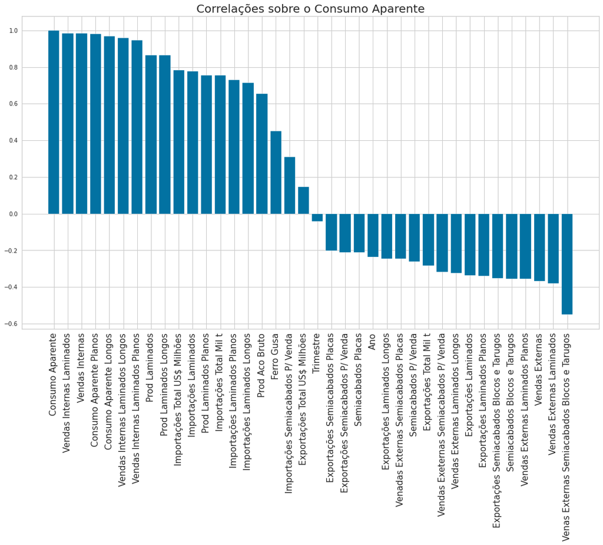

```python
# correlações apresentados em gráfico
plt.figure(figsize=(18, 10))
plt.bar(correlacao_consumo_aparente['Categoria'],correlacao_consumo_aparente['Correlação'])
plt.xticks(correlacao_consumo_aparente['Categoria'],rotation=90,fontsize=15);
plt.title('Correlações sobre o Consumo Aparente',fontsize=20)
```